```python
# import the necessary packages
import pandas as pd  # library used for data manipulation and analysis
import numpy as np  # library used for working with arrays.
import matplotlib.pyplot as plt  # library for plots and visualisations
import seaborn as sns  # library for visualisations

%matplotlib inline

import scipy.stats as stats  # this library contains a large number of probability distributions as well as a growing library of statistical functions.
```

**EDA Analysis**</a>

```python
# import the data
Enews_original = pd.read_csv('C:/Users/Konto/Documents/ESTUDOS/Texas university/Business Statistics/abtest.csv')
Enews_original.head()
```

|  | user_id | group | landing_page | time_spent_on_the_page | converted | language_preferred |
| --- | --- | --- | --- | --- | --- | --- |
| 0 | 546592 | control | old | 3.48 | yes | Spanish |
| 1 | 546468 | treatment | new | 7.13 | yes | English |
| 2 | 546462 | treatment | new | 4.40 | no | Spanish |
| 3 | 546567 | control | old | 3.02 | no | French |
| 4 | 546459 | treatment | new | 4.75 | yes | Spanish |

```python
# We need to perform calcuations for convertion rate, so we need to transform converted strings into values(converted 'yes' = 1, converted 'no' = 0)
Enews = Enews_original.replace({'converted': {'yes': 1,
                                'no': 0}})
```

```python
# I also shortned the column names for use. Data remains original. The data head shows 6 columns with different kinds of information
Enews.rename(columns={"user_id": "user", "landing_page": "page", "time_spent_on_the_page": "time", "language_preferred": "language"}, inplace=True)
Enews.head()
```

|  | user | group | page | time | converted | language |
| --- | --- | --- | --- | --- | --- | --- |
| 0 | 546592 | control | old | 3.48 | 1 | Spanish |
| 1 | 546468 | treatment | new | 7.13 | 1 | English |
| 2 | 546462 | treatment | new | 4.40 | 0 | Spanish |
| 3 | 546567 | control | old | 3.02 | 0 | French |
| 4 | 546459 | treatment | new | 4.75 | 1 | Spanish |

```python
# There are 100 observations for each column. Three columns have categorical data and three have numerical data.
# As we know from the explanation, user_id are all unique, which means each observation is one user.
# Having 100 different unique users, hence we can conclude that all observations are independent.
Enews.info()
```

```
<class 'pandas.core.frame.DataFrame'>
RangeIndex: 100 entries, 0 to 99
Data columns (total 6 columns):
 #   Column     Non-Null Count  Dtype
---  ------     --------------  -----
 0   user       100 non-null    int64
 1   group      100 non-null    object
 2   page       100 non-null    object
 3   time       100 non-null    float64
 4   converted  100 non-null    int64
 5   language   100 non-null    object
dtypes: float64(1), int64(2), object(3)
memory usage: 4.8+ KB
```

```python
# To make sure all the control group are seeing the old page and viceversa, let´s check a crosstab.
#There is a balanced amount of information for both groups and landing page, each one with 50 people (>30 observations required for normal distribution).
pd.crosstab(Enews['group'], Enews['page'])
```

| page group | new | old |
| --- | --- | --- |
| control | 0 | 50 |
| treatment | 50 | 0 |

```python
#There is also a balanced amount of information for the total number of people converted and not converted (>30 observations).
# Further tests will be performed below.
Enews.converted.value_counts()
```

```
1    55
0    45
Name: converted, dtype: int64
```

```python
#The three main languages appear almost the same amount of time, showing no high frequency for one specific language (>30 observations).
Enews.language.value_counts()
```

```
French     34
Spanish    34
English    32
Name: language, dtype: int64
```

```python
#Since time spent on the page is the only variable allow us a dispersion analysis, below you can see mean and 50% are close to each other.
# This implies a close to Zero skewness or symmetrical distribution.
Enews['time'].describe()
```

```
count    100.000000
mean       5.377800
std        2.378166
min        0.190000
25%        3.880000
50%        5.415000
75%        7.022500
max       10.710000
Name: time, dtype: float64
```

```python
#There are no missing values on the data set.
Enews.isnull().sum()
```

```
user         0
group        0
page         0
time         0
converted    0
language     0
dtype: int64
```

**EDA**</a>

### Question : Do the users spend more time on the new landing page than the old landing page?

A pivot table shows the summ of time spent on the landing pages (old and new) for the different languages and total.

```python
table = pd.pivot_table(Enews, index = ["page"],
              columns = "language" ,
              values = "time",
              aggfunc = "sum",
              margins = True,
              fill_value = "")
print(table)
```

```
language English  French Spanish     All
page
new       106.62  105.34    99.2  311.16
old        71.27   73.27   82.08  226.62
All       177.89  178.61  181.28  537.78
```

The total time spent on the pages are close between all languages (177.89 - 181.28). Though, the users spend more time on the new page (311.16) compared to the old one (226.62).

Answer: Yes, but this is a sample numerical information, in order to test it for a population we need to do an Hyphotesis testing.

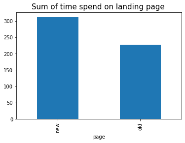

```python
#Visualization of time spend on the new landing page and the old landing page
Enews.groupby("page")["time"].sum().plot.bar()
plt.title("Sum of time spend on landing page ", fontsize=15)
plt.show()
```

### Question: Is the conversion rate (the proportion of users who visit the landing page and get converted) for the new page greater than the conversion rate for the old page?

The Data set has 100 distinct users, according to the text. If we count the number of users per page and covertion, we can see that 32 users for the new page were converted, while 23 users for the old page style.

Answer: Yes, but we also need to perform statistical analysis to confirm this hyphotesis.

```python
prop = pd.pivot_table(Enews, index = ["page","converted"],
              columns = "language" ,
              values = "user",
              aggfunc = "count",
              margins = True,
              fill_value = "")
print(prop)
```

```
language        English  French  Spanish  All
page converted
new  0                7       4        7   18
     1                9      13       10   32
old  0                5      13        9   27
     1               11       4        8   23
All                  32      34       34  100
```

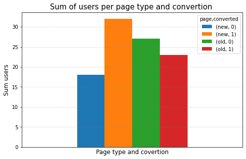

```python
# Visualization shows the column All ("Total"), which consider all users divided by the page and converted numbers.
gprop = pd.pivot_table(Enews, index = ["page","converted"],
              values = "user",
              aggfunc = "count")

ax = gprop.T.plot(kind='bar', figsize=(8,5))
plt.title("Sum of users per page type and convertion ", fontsize=15)
plt.xlabel("Page type and covertion", fontsize =12)
plt.ylabel("Sum users", fontsize =12 )
plt.grid(color='grey', linestyle='dotted', linewidth=0.5)
plt.xticks([])
plt.show()
```

### Question: Does the converted status depend on the preferred language?

Below we can see that the number of converted users is higher in English, followed by Spanish and last French. These numbers are very close to each other, therefore it is necessary to perform an statistical testing to confirm the hyphotesis.

Answer: It seems like English has a higher converted status, but it definately needs to be tested.

```python
prop = pd.pivot_table(Enews, index = ["converted"],
              columns = "language" ,
              values = "user",
              aggfunc = "count",
              margins = True,
              fill_value = "")
print(prop)
```

```
language   English  French  Spanish  All
converted
0               12      17       16   45
1               20      17       18   55
All             32      34       34  100
```

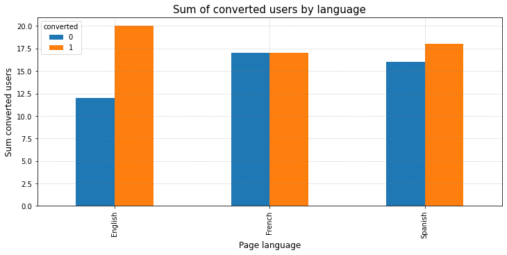

```python
# Visualization of number of converted and non-converted users per language
gprop = pd.pivot_table(Enews, index = ["converted"],
              columns = "language" ,
              values = "user",
              aggfunc = "count")

ax = gprop.T.plot(kind='bar', figsize=(12,5))
plt.title("Sum of converted users by language", fontsize=15)
plt.xlabel("Page language", fontsize=12)
plt.ylabel("Sum converted users", fontsize=12)
plt.grid(color='grey', linestyle='dotted', linewidth=0.5)
plt.show()
```

### Question: Is the mean time spent on the new page same for the different language users?

Below we can see that the mean time spent on the different languagees in the new page is very close. Answer: Based on the numbers, it is hard to confirm if the mean time spent on the new page is similar for the different language.We need to verify this statistically.

```python
table = pd.pivot_table(Enews, index = ["page"],
              columns = "language" ,
              values = "time",
              aggfunc = np.mean,
              margins = True,
              fill_value = "")
print(table)
```

```
language  English   French  Spanish     All
page
new       6.66375  6.19647  5.83529  6.2232
old       4.45437     4.31  4.82824  4.5324
All       5.55906  5.25324  5.33176  5.3778
```

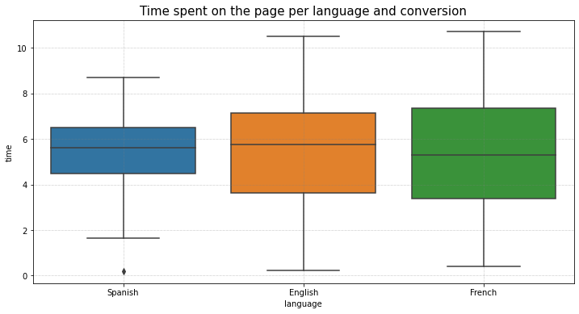

```python
# Visualization mean time spend on the different pages per language (independent if it is new or old)
# A Graph only with the mean time spend on the new page will be provided later.
fig, ax = plt.subplots(figsize = (12,6))
sns.boxplot(x="language", y="time", data = Enews)
plt.title("Time spent on the page per language and conversion", fontsize=15)
plt.grid(color='grey', linestyle='dotted', linewidth=0.5)
plt.show()
```

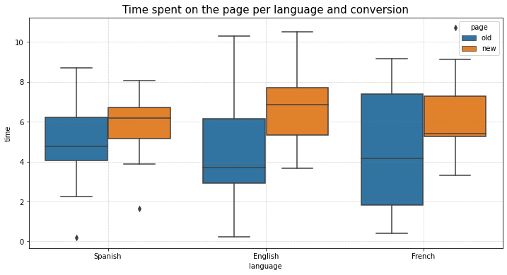

```python
# Because the company is interested only on the time spent on the new page, we can see them in orange.
# Though, an additional analysis may be helpful to check the mean time on new and onld pages according to language. As we see below they are more variate.
fig, ax = plt.subplots(figsize = (12,6))
sns.boxplot(x="language", y="time", hue = "page", data = Enews)
plt.title("Time spent on the page per language and conversion", fontsize=15)
plt.grid(color='grey', linestyle='dotted', linewidth=0.5)
plt.show()
```

Statistical analysis</a>

### Question : Do the users spend more time on the new landing page than the old landing page?

The selected test based on the given information is the 2-Sample independent t-test. Let's test whether the Z-test assumptions are satisfied or not:

- Continuous Data - Yes, the time is measured on a continuous scale.
- Normally distributed populations - Yes, all samples have more than 30 observations.
- Independent populations - As we are taking random samples for two different groups from unique users, the samples are independent.
- Unequal population standard deviations - Mean and Standard Deviation from sample are not the same(calculated below).
- Random sampling from the population - Yes, we are informed that the collected sample a simple random sample.

We will test the following hyphotesis: time spent on the different pages (new x old) are equal or not

We will test the null hypothesis

> $H_0:\mu_1=\mu_2$

```python
timeperpage = Enews.groupby('page')['time']

std_p = lambda x: np.std(x, ddof=0)              # Std. deviation of the proportion
se_p = lambda x: stats.sem(x, ddof=0)            # Std. error of the proportion (std / sqrt(n))
mean_p = lambda x: np.mean(x)

timeperpage = timeperpage.agg([np.sum, std_p, se_p, mean_p])
timeperpage.columns = ['total time', 'std_deviation', 'std_error', 'mean']


timeperpage.style.format('{:.3f}')
```

| page | total time | std_deviation | std_error | mean |
| --- | --- | --- | --- | --- |
| new | 311.160 | 1.799 | 0.254 | 6.223 |
| old | 226.620 | 2.556 | 0.361 | 4.532 |

```python
New = Enews.loc[(Enews['page'] == 'new') & (Enews['time'])]
Old = Enews.loc[(Enews['page'] == 'old') & (Enews['time'])]
```

```python
#import the required functions
from scipy.stats import ttest_ind

# find the p-value
test_stat, p_value = ttest_ind(New['time'], Old['time'], equal_var = False, alternative = 'greater')
print(f'z statistic: {test_stat:.2f}')
print(f'p-value: {p_value:.5f}')
```

```
z statistic: 3.79
p-value: 0.00014
```

As the p-value (~0.00014) is less than the level of significance, we can reject the null hypothesis. Hence, we do have enough evidence to support the claim that the time spent on the new website is higher than the time spent n the old one.

### Question: Is the conversion rate (the proportion of users who visit the landing page and get converted) for the new page greater than the conversion rate for the old page?

The selected test based on the given information is the Two proportion Z-Test which compares two samples proportions (covertion rate).

Given we don’t know if the new design will perform better or worse (or the same?) as our current design, we’ll choose a two-tailed test. Let's write the hypothesis Let $pn,po$ be the convertion rate of the new and old design , respectively.

The company will test the null hypothesis

> $H_0:pn =po$

against the alternate hypothesis

> $H_a:pn \neq po$

```python
conversion_rates = Enews.groupby('page')['converted']

std_p = lambda x: np.std(x, ddof=0)              # Std. deviation of the proportion
se_p = lambda x: stats.sem(x, ddof=0)            # Std. error of the proportion (std / sqrt(n))

conversion_rates = conversion_rates.agg([np.mean, std_p, se_p])
conversion_rates.columns = ['conversion_rate', 'std_deviation', 'std_error']


conversion_rates.style.format('{:.3f}')
```

| page | conversion_rate | std_deviation | std_error |
| --- | --- | --- | --- |
| new | 0.640 | 0.480 | 0.068 |
| old | 0.460 | 0.498 | 0.070 |

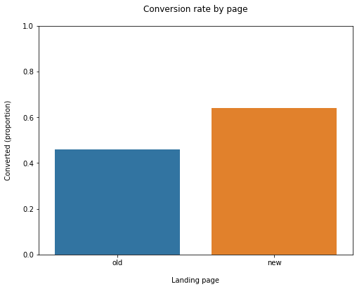

```python
# differently from the graph provided in EDA Analysis, this one shows the proportion of the convertion per page, not the number of converted users.
plt.figure(figsize=(8,6))

sns.barplot(x=Enews['page'], y=Enews['converted'], ci=False)

plt.ylim(0, 1.0)
plt.title('Conversion rate by page', pad=20)
plt.xlabel('Landing page', labelpad=15)
plt.ylabel('Converted (proportion)', labelpad=15);
```

```python
#Is this difference statistically significant?

from statsmodels.stats.proportion import proportions_ztest, proportion_confint
control_results = Enews[Enews['page'] == 'old']['converted']
treatment_results = Enews[Enews['page'] == 'new']['converted']
n_con = control_results.count()
n_treat = treatment_results.count()
successes = [control_results.sum(), treatment_results.sum()]
nobs = [n_con, n_treat]

z_stat, pval = proportions_ztest(successes, nobs=nobs, alternative = 'two-sided')
(lower_con, lower_treat), (upper_con, upper_treat) = proportion_confint(successes, nobs=nobs, alpha=0.05)

print(f'p-value: {pval:.3f}')
print(f'ci 95% for old landing page style: [{lower_con:.3f}, {upper_con:.3f}]')
print(f'ci 95% for new landing page style: [{lower_treat:.3f}, {upper_treat:.3f}]')
```

```
p-value: 0.070
ci 95% for old landing page style: [0.322, 0.598]
ci 95% for new landing page style: [0.507, 0.773]
```

### Conclusion:

Since our p-value=0.07 is above our α=0.05 threshold, we cannot reject the Null hypothesis, which means that our new design did not perform better than our old one.  
But, the p-value is very close to the level of significance, so let´s look additionally at the confidence interval for the new page :

([0.507, 0.773], or 50.7-77.3%) We notice that the lowest value is close to 50%, which means that there is still a posssibilty that the convertion rate is the same as the non convertion rate. Maybe a test with another sample, may give a more clear confirmation (or rejection).

### Question: Does the converted status depend on the preferred language?

The selected test based on the given information is Chi square test, which compares the proportion of samples. Let's test whether the assumptions are satisfied or not:

- Categorical variables - Yes
- Expected value of the number of sample observations in each level of the variable is at least 5 - Yes, the number of observations in each level is greater than 5.
- Random sampling from the population - Yes, already mentioned.

Let's write the null and alternative hypothesis

We will test the null hypothesis

> $H_0:$ converted status independent on language.

against the alternate hypothesis

> $H_a:$ converted status depends on language.

```python
Prop = pd.crosstab(Enews['converted'], Enews['language'], margins=False)
Prop
```

| language converted | English | French | Spanish |
| --- | --- | --- | --- |
| 0 | 12 | 17 | 16 |
| 1 | 20 | 17 | 18 |

```python
# import the required function
from scipy.stats import chi2_contingency

# find the p-value
chi2, pval, dof, exp_freq = chi2_contingency(Prop)
print(f'p-value: {pval:.3f}')
```

```
p-value: 0.569
```

As the p-value is far greater than the level of significance, we fail to reject the null hypothesis. The converted status is independent on language.

### Question: Is the mean time spent on the new page same for the different language users?

The selected test based on the given information is Anova Test

- Anova test is used to determine wether the means of more than two independent populations are significantly different.
- The populations are normally distributed - Yes, the normality assumption is verified using the Shapiro-Wilk’s test.
- Samples are independent simple random samples - Yes, we are informed that the collected sample is a simple random sample.
- Population variances are equal - Yes, the homogeneity of variance assumption is verified using the Levene's test. We will test the null hypothesis

> $H_0: \mu_1 = \mu_2 = \mu_3$

against the alternative hypothesis

> $H_a: $ At least one mean times are not equal

```python
# since we want the mean time on the new page, we need to create a data set only with the new page information.
Aonew = Enews[Enews['page'] == "new"]
Aonew.head()
```

|  | user | group | page | time | converted | language |
| --- | --- | --- | --- | --- | --- | --- |
| 1 | 546468 | treatment | new | 7.13 | 1 | English |
| 2 | 546462 | treatment | new | 4.40 | 0 | Spanish |
| 4 | 546459 | treatment | new | 4.75 | 1 | Spanish |
| 6 | 546448 | treatment | new | 5.25 | 1 | French |
| 8 | 546461 | treatment | new | 10.71 | 1 | French |

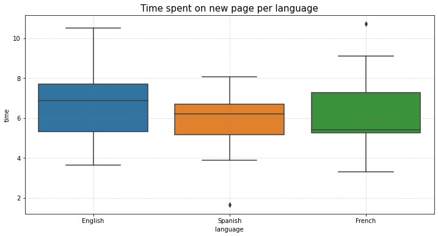

```python
# Visualization mean time spend on the new page on different language

fig, ax = plt.subplots(figsize = (12,6))
sns.boxplot(x="language", y="time", data = Aonew)
plt.title("Time spent on new page per language", fontsize=15)
plt.grid(color='grey', linestyle='dotted', linewidth=0.5)
plt.show()
```

```python
# Assumption 1: Normality
# import the required function
from scipy import stats

# find the p-value
w, p_value = stats.shapiro(Aonew['time'])
print('The p-value is', p_value)
```

```
The p-value is 0.8040016293525696
```

```python
#Assumption 2: Homogeneity of Variance
#import the required function
from scipy.stats import levene
statistic, p_value = levene( Aonew['time'][Aonew['language']=="English"],
                                   Aonew['time'][Aonew['language']=="French"],
                                   Aonew['time'][Aonew['language']=="Spanish"])
# find the p-value
print('The p-value is', p_value)
```

```
The p-value is 0.46711357711340173
```

```python
# perform one-way anova test
test_stat, p_value = stats.f_oneway(Aonew.loc[Aonew['language'] == 'English', 'time'],
                              Aonew.loc[Aonew['language'] == "French", 'time'],
                              Aonew.loc[Aonew['language']=="Spanish", 'time'])
print('The p-value is ', p_value)
```

```
The p-value is  0.43204138694325955
```

### Conclusion

- Shapiro test confirms the normality (p-value > 0.05)
- Levene test confirms the homogeneity of variance (p-value > 0.05)
- One Way test confirms that p-value is higher than the level of signinficance, therefore we can not reject the null hypothesis. The mean time spent on the new page for the different languages are similar.

# Now lets look at the time spent on new pages , but also on the old pages, for the different languages.

It is necessary to create a file with the six different categories, because if we use the original data, we will not calcuate the test for all the variables, we will simply calculate for the languages and time (no distinction on new or old).

```python
Enews2 = Enews.copy()
```

```python
Enews2['Anova'] = Enews2['page'].map(str) + ' ' + Enews2['language'].map(str)
```

```python
# The file has six categories in the Anova column (tested with Enews2.unique())
Enews2.head()
```

|  | user | group | page | time | converted | language | Anova |
| --- | --- | --- | --- | --- | --- | --- | --- |
| 0 | 546592 | control | old | 3.48 | 1 | Spanish | old Spanish |
| 1 | 546468 | treatment | new | 7.13 | 1 | English | new English |
| 2 | 546462 | treatment | new | 4.40 | 0 | Spanish | new Spanish |
| 3 | 546567 | control | old | 3.02 | 0 | French | old French |
| 4 | 546459 | treatment | new | 4.75 | 1 | Spanish | new Spanish |

```python
# Assumption 1: Normality
# import the required function
from scipy import stats

# find the p-value
w, p_value = stats.shapiro(Enews2['time'])
print('The p-value is', p_value)
```

```
The p-value is 0.5643684267997742
```

```python
#Assumption 2: Homogeneity of Variance
#import the required function
from scipy.stats import levene
statistic, p_value = levene(Enews2['time'][Enews2['language'] == "old English"],
                            Enews2['time'][Enews2['language'] == "old Spanish"],
                            Enews2['time'][Enews2['language'] == "old French"],
                            Enews2['time'][Enews2['language'] == "new English"],
                            Enews2['time'][Enews2['language'] == "new French"],
                            Enews2['time'][Enews2['language'] == "new Spanish"])
# find the p-value
print('The p-value is', p_value)
```

```
The p-value is nan
```

```python
# perform one-way anova test
test_stat, p_value = stats.f_oneway(Enews2.loc[Enews2['Anova'] == 'old English', 'time'],
                            Enews2.loc[Enews2['Anova'] == 'old Spanish', 'time'],
                            Enews2.loc[Enews2['Anova'] == 'old French', 'time'],
                            Enews2.loc[Enews2['Anova'] == 'new English', 'time'],
                            Enews2.loc[Enews2['Anova'] == 'new Spanish', 'time'],
                            Enews2.loc[Enews2['Anova'] == 'new French', 'time'])
print('The p-value is ', p_value)
```

```
The p-value is  0.012044401709073543
```

```python
#import the required function
from statsmodels.stats.multicomp import pairwise_tukeyhsd

# perform multiple pairwise comparison (Tukey HSD)
m_comp = pairwise_tukeyhsd(endog = Enews2['time'], groups = Enews2['Anova'], alpha = 0.05)
print(m_comp)
```

```
     Multiple Comparison of Means - Tukey HSD, FWER=0.05
=============================================================
   group1      group2   meandiff p-adj   lower  upper  reject
-------------------------------------------------------------
new English  new French  -0.4673    0.9  -2.758 1.8234  False
new English new Spanish  -0.8285  0.899 -3.1192 1.4622  False
new English old English  -2.2094 0.0726 -4.5345 0.1158  False
new English  old French  -2.3537 0.0404 -4.6445 -0.063   True
new English old Spanish  -1.8355  0.192 -4.1262 0.4552  False
 new French new Spanish  -0.3612    0.9 -2.6169 1.8946  False
 new French old English  -1.7421 0.2418 -4.0328 0.5486  False
 new French  old French  -1.8865 0.1556 -4.1422 0.3693  False
 new French old Spanish  -1.3682 0.4933  -3.624 0.8875  False
new Spanish old English  -1.3809 0.4997 -3.6716 0.9098  False
new Spanish  old French  -1.5253 0.3698  -3.781 0.7304  False
new Spanish old Spanish  -1.0071 0.7586 -3.2628 1.2487  False
old English  old French  -0.1444    0.9 -2.4351 2.1463  False
old English old Spanish   0.3739    0.9 -1.9168 2.6646  False
 old French old Spanish   0.5182    0.9 -1.7375  2.774  False
-------------------------------------------------------------
```